# Risk Factor Analysis

## Outcome Variable

**Outcome Variable:** sstunted

## Predictor Variables

**Intervention Variable:** cleanck

**Adjustment Set:**

unadjusted

## Stratifying Variables

The analysis was stratified on these variable(s):

- agecat
- studyid
- country

## Data Summary

| agecat | studyid | country | cleanck | sstunted | n_cell | n |
| --- | --- | --- | --- | --- | --- | --- |
| Birth | ki0047075b-MAL-ED | PERU | 0 | 0 | 1 | 2 |
| Birth | ki0047075b-MAL-ED | PERU | 0 | 1 | 0 | 2 |
| Birth | ki0047075b-MAL-ED | PERU | 1 | 0 | 1 | 2 |
| Birth | ki0047075b-MAL-ED | PERU | 1 | 1 | 0 | 2 |
| Birth | ki0047075b-MAL-ED | SOUTH AFRICA | 0 | 0 | 1 | 2 |
| Birth | ki0047075b-MAL-ED | SOUTH AFRICA | 0 | 1 | 0 | 2 |
| Birth | ki0047075b-MAL-ED | SOUTH AFRICA | 1 | 0 | 1 | 2 |
| Birth | ki0047075b-MAL-ED | SOUTH AFRICA | 1 | 1 | 0 | 2 |
| Birth | ki1000108-CMC-V-BCS-2002 | INDIA | 0 | 0 | 50 | 90 |
| Birth | ki1000108-CMC-V-BCS-2002 | INDIA | 0 | 1 | 2 | 90 |
| Birth | ki1000108-CMC-V-BCS-2002 | INDIA | 1 | 0 | 37 | 90 |
| Birth | ki1000108-CMC-V-BCS-2002 | INDIA | 1 | 1 | 1 | 90 |
| Birth | ki1000108-IRC | INDIA | 0 | 0 | 154 | 378 |
| Birth | ki1000108-IRC | INDIA | 0 | 1 | 6 | 378 |
| Birth | ki1000108-IRC | INDIA | 1 | 0 | 209 | 378 |
| Birth | ki1000108-IRC | INDIA | 1 | 1 | 9 | 378 |
| Birth | ki1017093c-NIH-Crypto | BANGLADESH | 0 | 0 | 7 | 20 |
| Birth | ki1017093c-NIH-Crypto | BANGLADESH | 0 | 1 | 1 | 20 |
| Birth | ki1017093c-NIH-Crypto | BANGLADESH | 1 | 0 | 12 | 20 |
| Birth | ki1017093c-NIH-Crypto | BANGLADESH | 1 | 1 | 0 | 20 |
| 6 months | ki0047075b-MAL-ED | SOUTH AFRICA | 0 | 0 | 0 | 1 |
| 6 months | ki0047075b-MAL-ED | SOUTH AFRICA | 0 | 1 | 0 | 1 |
| 6 months | ki0047075b-MAL-ED | SOUTH AFRICA | 1 | 0 | 1 | 1 |
| 6 months | ki0047075b-MAL-ED | SOUTH AFRICA | 1 | 1 | 0 | 1 |
| 6 months | ki1000108-CMC-V-BCS-2002 | INDIA | 0 | 0 | 178 | 369 |
| 6 months | ki1000108-CMC-V-BCS-2002 | INDIA | 0 | 1 | 28 | 369 |
| 6 months | ki1000108-CMC-V-BCS-2002 | INDIA | 1 | 0 | 149 | 369 |
| 6 months | ki1000108-CMC-V-BCS-2002 | INDIA | 1 | 1 | 14 | 369 |
| 6 months | ki1000108-IRC | INDIA | 0 | 0 | 154 | 398 |
| 6 months | ki1000108-IRC | INDIA | 0 | 1 | 14 | 398 |
| 6 months | ki1000108-IRC | INDIA | 1 | 0 | 216 | 398 |
| 6 months | ki1000108-IRC | INDIA | 1 | 1 | 14 | 398 |
| 6 months | ki1017093b-PROVIDE | BANGLADESH | 0 | 0 | 94 | 583 |
| 6 months | ki1017093b-PROVIDE | BANGLADESH | 0 | 1 | 7 | 583 |
| 6 months | ki1017093b-PROVIDE | BANGLADESH | 1 | 0 | 475 | 583 |
| 6 months | ki1017093b-PROVIDE | BANGLADESH | 1 | 1 | 7 | 583 |
| 6 months | ki1017093c-NIH-Crypto | BANGLADESH | 0 | 0 | 211 | 545 |
| 6 months | ki1017093c-NIH-Crypto | BANGLADESH | 0 | 1 | 5 | 545 |
| 6 months | ki1017093c-NIH-Crypto | BANGLADESH | 1 | 0 | 318 | 545 |
| 6 months | ki1017093c-NIH-Crypto | BANGLADESH | 1 | 1 | 11 | 545 |
| 6 months | ki1113344-GMS-Nepal | NEPAL | 0 | 0 | 956 | 1008 |
| 6 months | ki1113344-GMS-Nepal | NEPAL | 0 | 1 | 36 | 1008 |
| 6 months | ki1113344-GMS-Nepal | NEPAL | 1 | 0 | 16 | 1008 |
| 6 months | ki1113344-GMS-Nepal | NEPAL | 1 | 1 | 0 | 1008 |
| 24 months | ki0047075b-MAL-ED | SOUTH AFRICA | 0 | 0 | 0 | 1 |
| 24 months | ki0047075b-MAL-ED | SOUTH AFRICA | 0 | 1 | 0 | 1 |
| 24 months | ki0047075b-MAL-ED | SOUTH AFRICA | 1 | 0 | 1 | 1 |
| 24 months | ki0047075b-MAL-ED | SOUTH AFRICA | 1 | 1 | 0 | 1 |
| 24 months | ki1000108-CMC-V-BCS-2002 | INDIA | 0 | 0 | 121 | 372 |
| 24 months | ki1000108-CMC-V-BCS-2002 | INDIA | 0 | 1 | 88 | 372 |
| 24 months | ki1000108-CMC-V-BCS-2002 | INDIA | 1 | 0 | 128 | 372 |
| 24 months | ki1000108-CMC-V-BCS-2002 | INDIA | 1 | 1 | 35 | 372 |
| 24 months | ki1000108-IRC | INDIA | 0 | 0 | 150 | 400 |
| 24 months | ki1000108-IRC | INDIA | 0 | 1 | 19 | 400 |
| 24 months | ki1000108-IRC | INDIA | 1 | 0 | 210 | 400 |
| 24 months | ki1000108-IRC | INDIA | 1 | 1 | 21 | 400 |
| 24 months | ki1017093b-PROVIDE | BANGLADESH | 0 | 0 | 76 | 577 |
| 24 months | ki1017093b-PROVIDE | BANGLADESH | 0 | 1 | 22 | 577 |
| 24 months | ki1017093b-PROVIDE | BANGLADESH | 1 | 0 | 452 | 577 |
| 24 months | ki1017093b-PROVIDE | BANGLADESH | 1 | 1 | 27 | 577 |
| 24 months | ki1017093c-NIH-Crypto | BANGLADESH | 0 | 0 | 200 | 410 |
| 24 months | ki1017093c-NIH-Crypto | BANGLADESH | 0 | 1 | 11 | 410 |
| 24 months | ki1017093c-NIH-Crypto | BANGLADESH | 1 | 0 | 190 | 410 |
| 24 months | ki1017093c-NIH-Crypto | BANGLADESH | 1 | 1 | 9 | 410 |
| 24 months | ki1113344-GMS-Nepal | NEPAL | 0 | 0 | 784 | 892 |
| 24 months | ki1113344-GMS-Nepal | NEPAL | 0 | 1 | 94 | 892 |
| 24 months | ki1113344-GMS-Nepal | NEPAL | 1 | 0 | 14 | 892 |
| 24 months | ki1113344-GMS-Nepal | NEPAL | 1 | 1 | 0 | 892 |

The following strata were considered:

- agecat: 24 months, studyid: ki0047075b-MAL-ED, country: SOUTH AFRICA
- agecat: 24 months, studyid: ki1000108-CMC-V-BCS-2002, country: INDIA
- agecat: 24 months, studyid: ki1000108-IRC, country: INDIA
- agecat: 24 months, studyid: ki1017093b-PROVIDE, country: BANGLADESH
- agecat: 24 months, studyid: ki1017093c-NIH-Crypto, country: BANGLADESH
- agecat: 24 months, studyid: ki1113344-GMS-Nepal, country: NEPAL
- agecat: 6 months, studyid: ki0047075b-MAL-ED, country: SOUTH AFRICA
- agecat: 6 months, studyid: ki1000108-CMC-V-BCS-2002, country: INDIA
- agecat: 6 months, studyid: ki1000108-IRC, country: INDIA
- agecat: 6 months, studyid: ki1017093b-PROVIDE, country: BANGLADESH
- agecat: 6 months, studyid: ki1017093c-NIH-Crypto, country: BANGLADESH
- agecat: 6 months, studyid: ki1113344-GMS-Nepal, country: NEPAL
- agecat: Birth, studyid: ki0047075b-MAL-ED, country: PERU
- agecat: Birth, studyid: ki0047075b-MAL-ED, country: SOUTH AFRICA
- agecat: Birth, studyid: ki1000108-CMC-V-BCS-2002, country: INDIA
- agecat: Birth, studyid: ki1000108-IRC, country: INDIA
- agecat: Birth, studyid: ki1017093c-NIH-Crypto, country: BANGLADESH

### Dropped Strata

Some strata were dropped due to rare outcomes:

- agecat: Birth, studyid: ki0047075b-MAL-ED, country: PERU
- agecat: Birth, studyid: ki0047075b-MAL-ED, country: SOUTH AFRICA
- agecat: Birth, studyid: ki1000108-CMC-V-BCS-2002, country: INDIA
- agecat: Birth, studyid: ki1017093c-NIH-Crypto, country: BANGLADESH
- agecat: 6 months, studyid: ki0047075b-MAL-ED, country: SOUTH AFRICA
- agecat: 6 months, studyid: ki1113344-GMS-Nepal, country: NEPAL
- agecat: 24 months, studyid: ki0047075b-MAL-ED, country: SOUTH AFRICA
- agecat: 24 months, studyid: ki1113344-GMS-Nepal, country: NEPAL

## Methods Detail

We’re interested in the causal parameters $E[Y_a]$ for all values of $a \in \mathcal{A}$. These parameters represent the mean outcome if, possibly contrary to fact, we intervened to set all units to have $A=a$. Under the randomization and positivity assumptions, these are identified by the statistical parameters $\psi_a=E_W[E_{Y|A,W}(Y|A=a,W)]$. In addition, we’re interested in the mean of $Y$, $E[Y]$ under no intervention (the observed mean). We will estimate these parameters by using SuperLearner to fit the relevant likelihood factors – $E_{Y|A,W}(Y|A=a,W)$ and $p(A=a|W)$, and then updating our likelihood fit using a joint TMLE.

For unadjusted analyses ($W=\{\}$), initial likelihoods were estimated using Lrnr_glm to estimate the simple $E(Y|A)$ and Lrnr_mean to estimate $p(A)$. For adjusted analyses, a small library containing Lrnr_glmnet, Lrnr_xgboost, and Lrnr_mean was used.

Having estimated these parameters, we will then use the delta method to estimate relative risks and attributable risks relative to a prespecified baseline level of $A$.

# Results Detail

## Results Plots

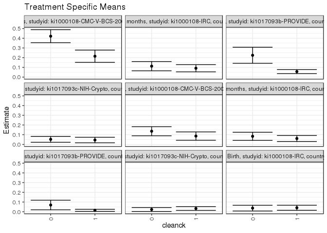

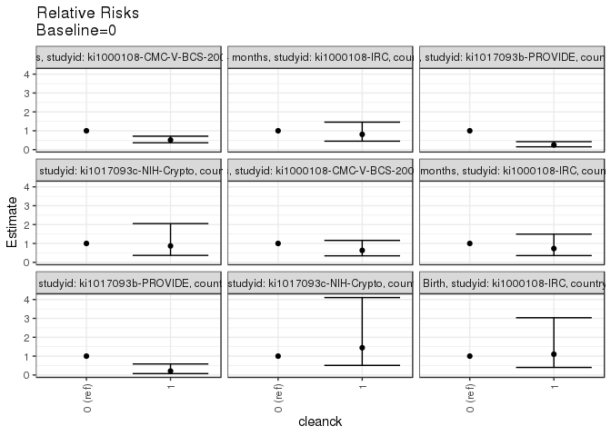

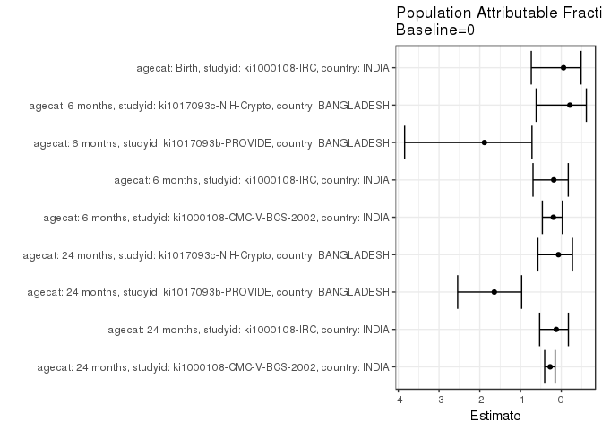

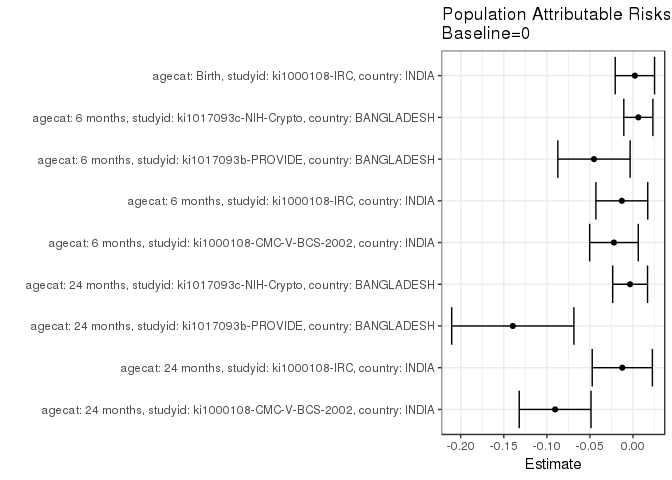

## Results Table

### Parameter: TSM

| agecat | studyid | country | intervention_level | baseline_level | estimate | ci_lower | ci_upper |
| --- | --- | --- | --- | --- | --- | --- | --- |
| Birth | ki1000108-IRC | INDIA | 0 | NA | 0.0375000 | 0.0080233 | 0.0669767 |
| Birth | ki1000108-IRC | INDIA | 1 | NA | 0.0412844 | 0.0148400 | 0.0677288 |
| 6 months | ki1000108-CMC-V-BCS-2002 | INDIA | 0 | NA | 0.1359223 | 0.0890598 | 0.1827848 |
| 6 months | ki1000108-CMC-V-BCS-2002 | INDIA | 1 | NA | 0.0858896 | 0.0428158 | 0.1289634 |
| 6 months | ki1000108-IRC | INDIA | 0 | NA | 0.0833333 | 0.0414872 | 0.1251794 |
| 6 months | ki1000108-IRC | INDIA | 1 | NA | 0.0608696 | 0.0299315 | 0.0918077 |
| 6 months | ki1017093b-PROVIDE | BANGLADESH | 0 | NA | 0.0693069 | 0.0197332 | 0.1188807 |
| 6 months | ki1017093b-PROVIDE | BANGLADESH | 1 | NA | 0.0145228 | 0.0038336 | 0.0252120 |
| 6 months | ki1017093c-NIH-Crypto | BANGLADESH | 0 | NA | 0.0231481 | 0.0030761 | 0.0432202 |
| 6 months | ki1017093c-NIH-Crypto | BANGLADESH | 1 | NA | 0.0334347 | 0.0139917 | 0.0528776 |
| 24 months | ki1000108-CMC-V-BCS-2002 | INDIA | 0 | NA | 0.4210526 | 0.3540260 | 0.4880792 |
| 24 months | ki1000108-CMC-V-BCS-2002 | INDIA | 1 | NA | 0.2147239 | 0.1516006 | 0.2778473 |
| 24 months | ki1000108-IRC | INDIA | 0 | NA | 0.1124260 | 0.0647408 | 0.1601113 |
| 24 months | ki1000108-IRC | INDIA | 1 | NA | 0.0909091 | 0.0537904 | 0.1280278 |
| 24 months | ki1017093b-PROVIDE | BANGLADESH | 0 | NA | 0.2244898 | 0.1418092 | 0.3071704 |
| 24 months | ki1017093b-PROVIDE | BANGLADESH | 1 | NA | 0.0563674 | 0.0356959 | 0.0770390 |
| 24 months | ki1017093c-NIH-Crypto | BANGLADESH | 0 | NA | 0.0521327 | 0.0221020 | 0.0821634 |
| 24 months | ki1017093c-NIH-Crypto | BANGLADESH | 1 | NA | 0.0452261 | 0.0163195 | 0.0741327 |

### Parameter: E(Y)

| agecat | studyid | country | intervention_level | baseline_level | estimate | ci_lower | ci_upper |
| --- | --- | --- | --- | --- | --- | --- | --- |
| Birth | ki1000108-IRC | INDIA | NA | NA | 0.0396825 | 0.0199772 | 0.0593879 |
| 6 months | ki1000108-CMC-V-BCS-2002 | INDIA | NA | NA | 0.1138211 | 0.0813725 | 0.1462698 |
| 6 months | ki1000108-IRC | INDIA | NA | NA | 0.0703518 | 0.0451953 | 0.0955082 |
| 6 months | ki1017093b-PROVIDE | BANGLADESH | NA | NA | 0.0240137 | 0.0115761 | 0.0364514 |
| 6 months | ki1017093c-NIH-Crypto | BANGLADESH | NA | NA | 0.0293578 | 0.0151725 | 0.0435431 |
| 24 months | ki1000108-CMC-V-BCS-2002 | INDIA | NA | NA | 0.3306452 | 0.2827744 | 0.3785159 |
| 24 months | ki1000108-IRC | INDIA | NA | NA | 0.1000000 | 0.0705637 | 0.1294363 |
| 24 months | ki1017093b-PROVIDE | BANGLADESH | NA | NA | 0.0849220 | 0.0621566 | 0.1076874 |
| 24 months | ki1017093c-NIH-Crypto | BANGLADESH | NA | NA | 0.0487805 | 0.0279044 | 0.0696566 |

### Parameter: RR

| agecat | studyid | country | intervention_level | baseline_level | estimate | ci_lower | ci_upper |
| --- | --- | --- | --- | --- | --- | --- | --- |
| Birth | ki1000108-IRC | INDIA | 0 | 0 | 1.0000000 | 1.0000000 | 1.0000000 |
| Birth | ki1000108-IRC | INDIA | 1 | 0 | 1.1009174 | 0.3993811 | 3.0347432 |
| 6 months | ki1000108-CMC-V-BCS-2002 | INDIA | 0 | 0 | 1.0000000 | 1.0000000 | 1.0000000 |
| 6 months | ki1000108-CMC-V-BCS-2002 | INDIA | 1 | 0 | 0.6319018 | 0.3438312 | 1.1613255 |
| 6 months | ki1000108-IRC | INDIA | 0 | 0 | 1.0000000 | 1.0000000 | 1.0000000 |
| 6 months | ki1000108-IRC | INDIA | 1 | 0 | 0.7304348 | 0.3575055 | 1.4923824 |
| 6 months | ki1017093b-PROVIDE | BANGLADESH | 0 | 0 | 1.0000000 | 1.0000000 | 1.0000000 |
| 6 months | ki1017093b-PROVIDE | BANGLADESH | 1 | 0 | 0.2095436 | 0.0750832 | 0.5847978 |
| 6 months | ki1017093c-NIH-Crypto | BANGLADESH | 0 | 0 | 1.0000000 | 1.0000000 | 1.0000000 |
| 6 months | ki1017093c-NIH-Crypto | BANGLADESH | 1 | 0 | 1.4443769 | 0.5084549 | 4.1030675 |
| 24 months | ki1000108-CMC-V-BCS-2002 | INDIA | 0 | 0 | 1.0000000 | 1.0000000 | 1.0000000 |
| 24 months | ki1000108-CMC-V-BCS-2002 | INDIA | 1 | 0 | 0.5099693 | 0.3650530 | 0.7124136 |
| 24 months | ki1000108-IRC | INDIA | 0 | 0 | 1.0000000 | 1.0000000 | 1.0000000 |
| 24 months | ki1000108-IRC | INDIA | 1 | 0 | 0.8086124 | 0.4488010 | 1.4568909 |
| 24 months | ki1017093b-PROVIDE | BANGLADESH | 0 | 0 | 1.0000000 | 1.0000000 | 1.0000000 |
| 24 months | ki1017093b-PROVIDE | BANGLADESH | 1 | 0 | 0.2510913 | 0.1493166 | 0.4222360 |
| 24 months | ki1017093c-NIH-Crypto | BANGLADESH | 0 | 0 | 1.0000000 | 1.0000000 | 1.0000000 |
| 24 months | ki1017093c-NIH-Crypto | BANGLADESH | 1 | 0 | 0.8675194 | 0.3669417 | 2.0509796 |

### Parameter: PAR

| agecat | studyid | country | intervention_level | baseline_level | estimate | ci_lower | ci_upper |
| --- | --- | --- | --- | --- | --- | --- | --- |
| Birth | ki1000108-IRC | INDIA | 0 | NA | 0.0021825 | -0.0206565 | 0.0250216 |
| 6 months | ki1000108-CMC-V-BCS-2002 | INDIA | 0 | NA | -0.0221012 | -0.0503324 | 0.0061300 |
| 6 months | ki1000108-IRC | INDIA | 0 | NA | -0.0129816 | -0.0430753 | 0.0171121 |
| 6 months | ki1017093b-PROVIDE | BANGLADESH | 0 | NA | -0.0452932 | -0.0872545 | -0.0033319 |
| 6 months | ki1017093c-NIH-Crypto | BANGLADESH | 0 | NA | 0.0062097 | -0.0106651 | 0.0230844 |
| 24 months | ki1000108-CMC-V-BCS-2002 | INDIA | 0 | NA | -0.0904075 | -0.1320737 | -0.0487412 |
| 24 months | ki1000108-IRC | INDIA | 0 | NA | -0.0124260 | -0.0473394 | 0.0224874 |
| 24 months | ki1017093b-PROVIDE | BANGLADESH | 0 | NA | -0.1395678 | -0.2105059 | -0.0686297 |
| 24 months | ki1017093c-NIH-Crypto | BANGLADESH | 0 | NA | -0.0033522 | -0.0235863 | 0.0168818 |

### Parameter: PAF

| agecat | studyid | country | intervention_level | baseline_level | estimate | ci_lower | ci_upper |
| --- | --- | --- | --- | --- | --- | --- | --- |
| Birth | ki1000108-IRC | INDIA | 0 | NA | 0.0550000 | -0.7364417 | 0.4857155 |
| 6 months | ki1000108-CMC-V-BCS-2002 | INDIA | 0 | NA | -0.1941748 | -0.4645364 | 0.0262766 |
| 6 months | ki1000108-IRC | INDIA | 0 | NA | -0.1845238 | -0.6937111 | 0.1715844 |
| 6 months | ki1017093b-PROVIDE | BANGLADESH | 0 | NA | -1.8861386 | -3.8445706 | -0.7194086 |
| 6 months | ki1017093c-NIH-Crypto | BANGLADESH | 0 | NA | 0.2115162 | -0.6165433 | 0.6154098 |
| 24 months | ki1000108-CMC-V-BCS-2002 | INDIA | 0 | NA | -0.2734275 | -0.4076501 | -0.1520033 |
| 24 months | ki1000108-IRC | INDIA | 0 | NA | -0.1242604 | -0.5317178 | 0.1748079 |
| 24 months | ki1017093b-PROVIDE | BANGLADESH | 0 | NA | -1.6434819 | -2.5425694 | -0.9725786 |
| 24 months | ki1017093c-NIH-Crypto | BANGLADESH | 0 | NA | -0.0687204 | -0.5741547 | 0.2744276 |